# Umhlatuzana Sieve Analysis

Kyra Pazan

2026-09-10

```r
knitr::opts_chunk$set(echo = TRUE)
library(tidyverse)
```

```r
library(dplyr)
library(Kendall)
library(ggplot2)
library(ggpubr)
library(rmarkdown)
LSA_spits <- readRDS("LSAspits.rds")
MSA_spits <- readRDS("MSAspits.rds")
UMH_sieves <- readRDS("UMHsieves.rds")
UMH_allfinds <- readRDS("UMH_allfinds.rds")
gerrit <- readRDS("gerritpalette.rds")
```

## Download data

Raw data and the color palette are available for download below.

- Click here to download LSA_spits
- Click here to download MSA_spits
- Click here to download UMH_sieves
- Click here to download UMH_allfinds
- Click to download color palette

## Test for Proportions

We conducted a two-sample test for equality of proportions using the built-in *stats* package (2026), comparing the relative proportion of the technological sample before and after the MSA/LSA transition. Spits assigned to the transition were not included in this analysis.

```r
MSA_all <- c(sum(MSA_spits$All.big)+sum(MSA_spits$All.small))
LSA_all <- c(sum(LSA_spits$All.big)+sum(LSA_spits$All.small))
MSA_big <- sum(MSA_spits$All.big)
LSA_big <- sum(LSA_spits$All.big)
big <- c(MSA_big, LSA_big)
allartifacts <- c(MSA_all, LSA_all)
prop.test(big, n=allartifacts)
```

```
##
##  2-sample test for equality of proportions with continuity correction
##
## data:  big out of allartifacts
## X-squared = 371.49, df = 1, p-value < 2.2e-16
## alternative hypothesis: two.sided
## 95 percent confidence interval:
##  -0.1749027 -0.1423544
## sample estimates:
##    prop 1    prop 2
## 0.1599930 0.3186215
```

## Kendall’s rank correlation tests

We used Kendall’s rank correlation tests in the package *Kendall* (McLeod 2025) to assess correlations between the numbers of small and large finds across various raw materials and different time periods. Below are the results across the entire sequence, first for all materials, then separating quartz and nonquartz.

```r
Kendall(UMH_sieves$All.big, UMH_sieves$All.small)
```

```
## tau = 0.379, 2-sided pvalue =0.00032699
```

```r
Kendall(UMH_sieves$Quartz.big, UMH_sieves$Quartz.small)
```

```
## tau = 0.672, 2-sided pvalue =< 2.22e-16
```

```r
Kendall(UMH_sieves$Nonquartz.big, UMH_sieves$Nonquartz.small)
```

```
## tau = 0.637, 2-sided pvalue =< 2.22e-16
```

We then separated the final and late MSA spits (46-61) from the LSA spits (15-43), and performed the same set of correlations.

```r
range(LSA_spits$Spit)
```

```
## [1] 15 43
```

```r
Kendall(LSA_spits$All.big,LSA_spits$All.small)
```

```
## tau = 0.467, 2-sided pvalue =0.00093484
```

```r
Kendall(LSA_spits$Quartz.big,LSA_spits$Quartz.small)
```

```
## tau = 0.566, 2-sided pvalue =6.9618e-05
```

```r
Kendall(LSA_spits$Nonquartz.big, LSA_spits$Nonquartz.small)
```

```
## tau = 0.382, 2-sided pvalue =0.007473
```

```r
range(MSA_spits$Spit)
```

```
## [1] 46 61
```

```r
Kendall(MSA_spits$All.big,MSA_spits$All.small)
```

```
## tau = 0.494, 2-sided pvalue =0.00895
```

```r
Kendall(MSA_spits$Quartz.big,MSA_spits$Quartz.small)
```

```
## tau = 0.649, 2-sided pvalue =0.00074196
```

```r
Kendall(MSA_spits$Nonquartz.big,MSA_spits$Nonquartz.small)
```

```
## tau = 0.672, 2-sided pvalue =0.00036526
```

## Plot

Figure 1 is reproduced below, along with the associated code. The packages *ggplot2* (Wickham 2016) and *ggpubr* (Kassambara 2026) were both used in data visualization.

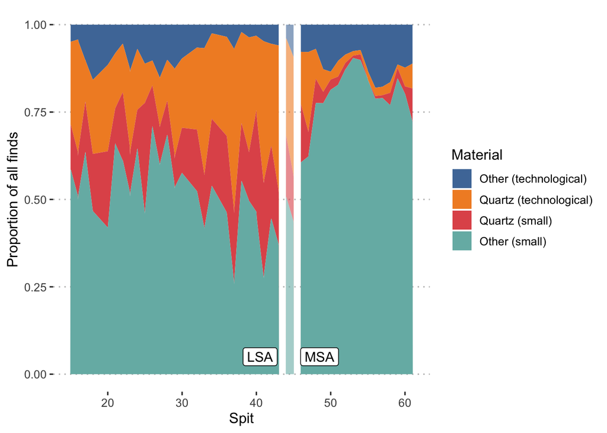

```r
allfinds.plot2 <-
ggplot()+
geom_area(UMH_allfinds, mapping = aes(x=Spit, y=Finds, fill=Material, alpha=Period), position = "fill")+
labs(x="Spit",y="Proportion of all finds", fill="Material")+
theme_pubclean()+
scale_fill_manual(values = gerrit, labels = c("Nonquartz.big" = "Other (technological)", "Quartz.big" = "Quartz (technological)", "Quartz.small" = "Quartz (small)", "Nonquartz.small" = "Other (small)"))+
scale_alpha_manual(values = c("LSA"=1, "Transition"=.6, "MSA"=1), guide = "none")+
annotate("label", x=40.5, y=.05, label="LSA", size=4)+
annotate("label", x = 48.5, y = .05, label="MSA", size = 4)+
theme(legend.position = "right")
allfinds.plot2
```

## Data

Data sets used in this document are printed below.

**MSA_spits**

|  | Spit | Period | All.big | All.small | Quartz.big | Quartz.small | Nonquartz.big | Nonquartz.small |
| --- | --- | --- | --- | --- | --- | --- | --- | --- |
| 29 | 46 | MSA | 88 | 298 | 58 | 64 | 30 | 234 |
| 30 | 47 | MSA | 106 | 239 | 79 | 24 | 27 | 215 |
| 31 | 48 | MSA | 67 | 366 | 37 | 30 | 30 | 336 |
| 32 | 49 | MSA | 89 | 374 | 30 | 15 | 59 | 359 |
| 33 | 50 | MSA | 91 | 489 | 13 | 17 | 78 | 472 |
| 34 | 51 | MSA | 76 | 436 | 23 | 12 | 53 | 424 |
| 35 | 52 | MSA | 70 | 575 | 15 | 12 | 55 | 563 |
| 36 | 53 | MSA | 41 | 421 | 6 | 3 | 35 | 418 |
| 37 | 54 | MSA | 42 | 453 | 6 | 8 | 36 | 445 |
| 38 | 55 | MSA | 44 | 235 | 7 | 0 | 37 | 235 |

[output cut: 6 more lines]

**LSA_spits**

|  | Spit | Period | All.big | All.small | Quartz.big | Quartz.small | Nonquartz.big | Nonquartz.small |
| --- | --- | --- | --- | --- | --- | --- | --- | --- |
| 1 | 15 | LSA | 47 | 117 | 39 | 21 | 8 | 96 |
| 2 | 16 | LSA | 18 | 30 | 16 | 6 | 2 | 24 |
| 3 | 17 | LSA | 26 | 92 | 14 | 17 | 12 | 75 |
| 4 | 18 | LSA | 61 | 104 | 35 | 27 | 26 | 77 |
| 5 | 20 | LSA | 63 | 111 | 43 | 38 | 20 | 73 |
| 6 | 21 | LSA | 41 | 130 | 27 | 17 | 14 | 113 |
| 7 | 22 | LSA | 39 | 162 | 28 | 39 | 11 | 123 |
| 8 | 23 | LSA | 22 | 37 | 14 | 7 | 8 | 30 |
| 9 | 24 | LSA | 35 | 109 | 25 | 16 | 10 | 93 |
| 10 | 25 | LSA | 36 | 125 | 18 | 51 | 18 | 74 |

[output cut: 16 more lines]

**UMH_sieves**

| Spit | Period | All.big | All.small | Quartz.big | Quartz.small | Nonquartz.big | Nonquartz.small |
| --- | --- | --- | --- | --- | --- | --- | --- |
| 15 | LSA | 47 | 117 | 39 | 21 | 8 | 96 |
| 16 | LSA | 18 | 30 | 16 | 6 | 2 | 24 |
| 17 | LSA | 26 | 92 | 14 | 17 | 12 | 75 |
| 18 | LSA | 61 | 104 | 35 | 27 | 26 | 77 |
| 20 | LSA | 63 | 111 | 43 | 38 | 20 | 73 |
| 21 | LSA | 41 | 130 | 27 | 17 | 14 | 113 |
| 22 | LSA | 39 | 162 | 28 | 39 | 11 | 123 |
| 23 | LSA | 22 | 37 | 14 | 7 | 8 | 30 |
| 24 | LSA | 35 | 109 | 25 | 16 | 10 | 93 |
| 25 | LSA | 36 | 125 | 18 | 51 | 18 | 74 |

[output cut: 34 more lines]

**UMH_allfinds**

| Spit | Period | All.big | All.small | Material | Finds |
| --- | --- | --- | --- | --- | --- |
| 15 | LSA | 47 | 117 | Quartz.big | 39 |
| 15 | LSA | 47 | 117 | Quartz.small | 21 |
| 15 | LSA | 47 | 117 | Nonquartz.big | 8 |
| 15 | LSA | 47 | 117 | Nonquartz.small | 96 |
| 16 | LSA | 18 | 30 | Quartz.big | 16 |
| 16 | LSA | 18 | 30 | Quartz.small | 6 |
| 16 | LSA | 18 | 30 | Nonquartz.big | 2 |
| 16 | LSA | 18 | 30 | Nonquartz.small | 24 |
| 17 | LSA | 26 | 92 | Quartz.big | 14 |
| 17 | LSA | 26 | 92 | Quartz.small | 17 |

[output cut: 166 more lines]

Kassambara, Alboukadel. 2026. *Ggpubr: ’Ggplot2’ Based Publication Ready Plots*. https://CRAN.R-project.org/package=ggpubr.

McLeod, A. I. 2025. *Kendall: Kendall Rank Correlation and Mann-Kendall Trend Test*. https://doi.org/10.32614/CRAN.package.Kendall.

R Core Team. 2026. *R: A Language and Environment for Statistical Computing*. https://doi.org/10.32614/R.manuals.

Wickham, Hadley. 2016. *Ggplot2: Elegant Graphics for Data Analysis*. https://ggplot2.tidyverse.org.